# ćwiczenie 7

Patrycja Sarga

25 kwietnia 2023

## Zadanie1

Przeanalizuj dane $mass.txt$ zawierające informacje dotyczące masy ciała (trzecia kolumna) oraz masy mózgu (druga kolumna) dla pewnych ssaków.

- narysuj wykres zależności trzeciej kolumny od drugiej, zbuduj model regresji liniowej (szukamy zależności masy ciała w oparciu o masę mózgu)
- przekształć wartości drugiej i trzeciej kolumny przez logarytm a następnie wykonaj regresję liniową (szukamy zależności masy ciała w oparciu o masę mózgu),
- skomentuj otrzymane modele a następnie dokonaj ich diagnostyki,
- jaka by była masa ciała ssaka, którego masa mózgu wynosi 62 (wg obu modeli)?

```r
data = read.table("D:/Documents/mass.txt", header = FALSE)
head(data)
```

```
##   V1      V2    V3
## 1  1   3.385  44.5
## 2  2   0.480  15.5
## 3  3   1.350   8.1
## 4  4 465.000 423.0
## 5  5  36.330 119.5
## 6  6  27.660 115.0
```

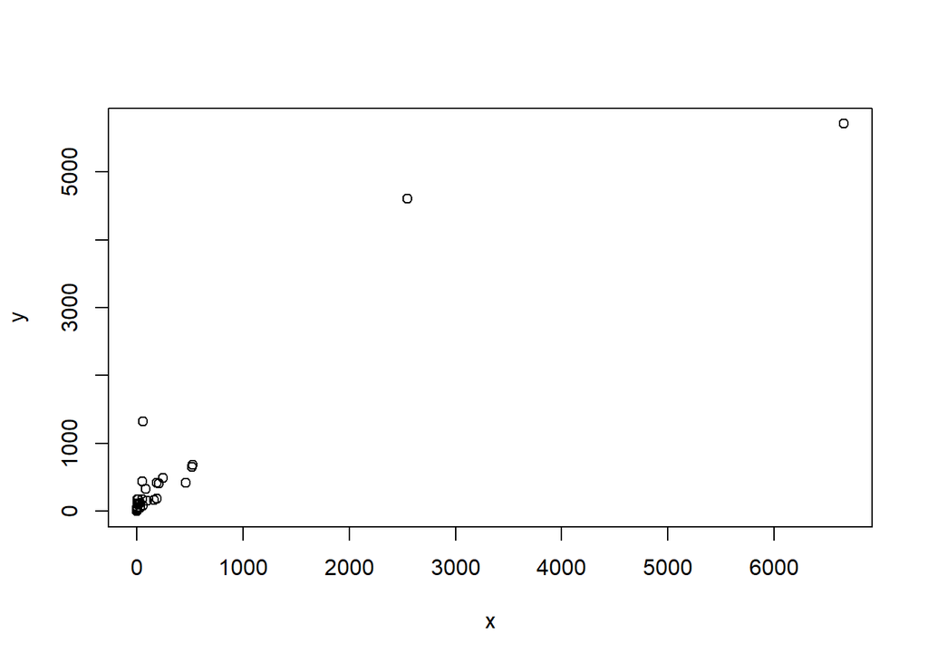

```r
options(repr.plot.width=4, repr.plot.height=4)
x = data$V2
y = data$V3
plot(x, y)
```

```r
cor(x,y) #spolczynnik korealcji Pearsona
```

```
## [1] 0.9341638
```

Otrzymujemy bardzo wysoki współczynnik korelacji Pearsona (dany wykazują zależność liniową), a Większa część dostępnych danych jet mocno skumulowana w wąskim zakresie, a reszta jest rozciągnięta do szerokiego zakresu, przez co nie możemy jasno określić czy dane mają charakter rozkładu normalnego, dlatego też przekształcamy dane.c mamy zależność liniową.

```r
lm.r = lm(y ~ x) #budujemy model regresji liniowej y=ax+b
print(summary(lm.r))
```

```
##
## Call:
## lm(formula = y ~ x)
##
## Residuals:
##     Min      1Q  Median      3Q     Max
## -810.07  -88.52  -79.64  -13.02 2050.33
##
## Coefficients:
##             Estimate Std. Error t value Pr(>|t|)
## (Intercept) 91.00440   43.55258    2.09   0.0409 *
## x            0.96650    0.04766   20.28   <2e-16 ***
## ---
## Signif. codes:  0 '***' 0.001 '**' 0.01 '*' 0.05 '.' 0.1 ' ' 1
##
## Residual standard error: 334.7 on 60 degrees of freedom
## Multiple R-squared:  0.8727, Adjusted R-squared:  0.8705
## F-statistic: 411.2 on 1 and 60 DF,  p-value: < 2.2e-16
```

Symbole * przy wartościach p-value sugerują, że mamy istotność statystyczną.

```r
print(coef(lm.r)) #same wspolczynniki
```

```
## (Intercept)           x
##  91.0043962   0.9664964
```

```r
confint(lm.r, level = 0.95) #przedzial ufnosci dla parametrow modelu
```

```
##                 2.5 %     97.5 %
## (Intercept) 3.8862623 178.122530
## x           0.8711564   1.061836
```

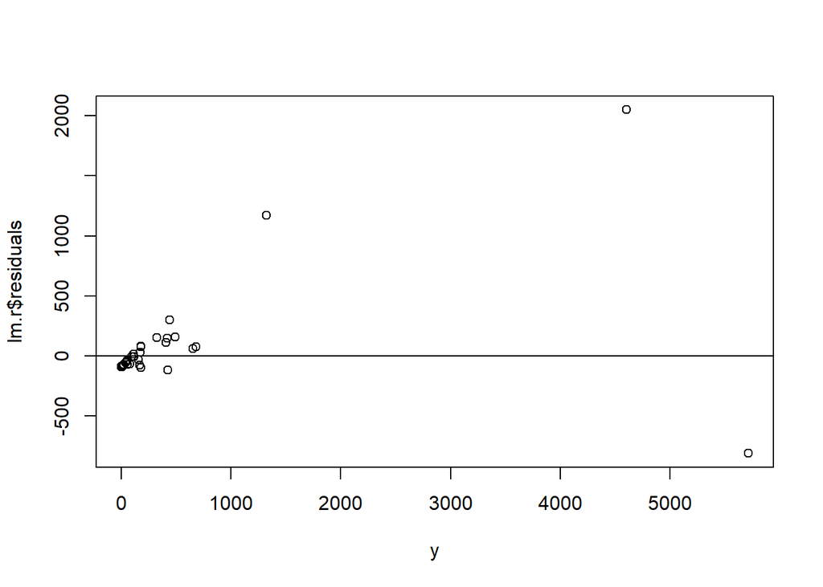

```r
plot(y, lm.r$residuals)
abline(h = 0) #dodaje y=0; punkty powinny byc rozrzucone symetrycznie wzgledem tej prostej
```

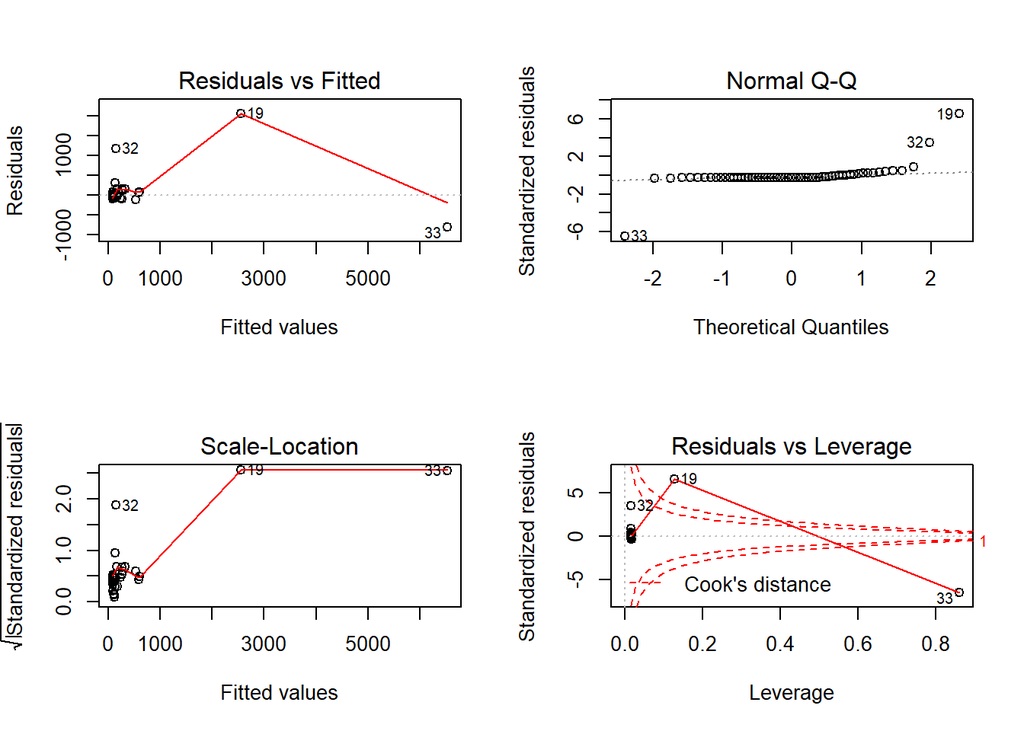

```r
options(repr.plot.width=10, repr.plot.height=5)

par(mfrow = c(2, 2));
plot(lm.r)
```

```r
#przewidywanie nowych wartosci
predict(lm.r, data.frame(x = 62), level = 0.95, interval = "confidence")
```

```
##        fit      lwr     upr
## 1 150.9272 64.90131 236.953
```

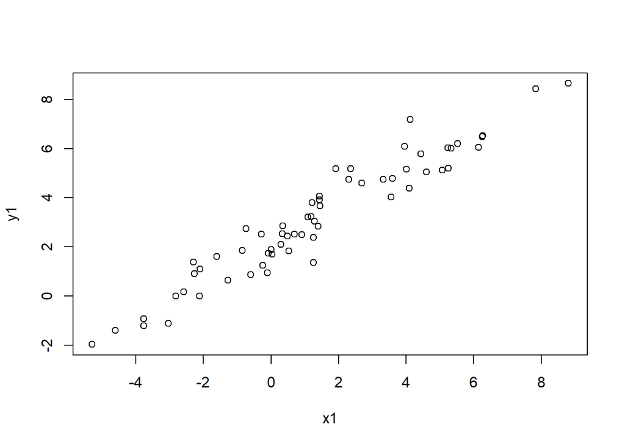

```r
x1 = log(x)
y1 = log(y)

plot(x1, y1)
```

```r
cor(x1,y1)
```

```
## [1] 0.9595748
```

```r
lm.r = lm(y1 ~ x1) #budujemy model regresji liniowej y=ax+b
print(summary(lm.r))
```

```
##
## Call:
## lm(formula = y1 ~ x1)
##
## Residuals:
##      Min       1Q   Median       3Q      Max
## -1.71550 -0.49228 -0.06162  0.43597  1.94829
##
## Coefficients:
##             Estimate Std. Error t value Pr(>|t|)
## (Intercept)  2.13479    0.09604   22.23   <2e-16 ***
## x1           0.75169    0.02846   26.41   <2e-16 ***
## ---
## Signif. codes:  0 '***' 0.001 '**' 0.01 '*' 0.05 '.' 0.1 ' ' 1
##
## Residual standard error: 0.6943 on 60 degrees of freedom
## Multiple R-squared:  0.9208, Adjusted R-squared:  0.9195
## F-statistic: 697.4 on 1 and 60 DF,  p-value: < 2.2e-16
```

```r
print(coef(lm.r)) #same wspolczynniki
```

```
## (Intercept)          x1
##   2.1347887   0.7516859
```

```r
confint(lm.r, level = 0.95) #przedzial ufnosci dla parametrow modelu
```

```
##                 2.5 %    97.5 %
## (Intercept) 1.9426733 2.3269041
## x1          0.6947503 0.8086215
```

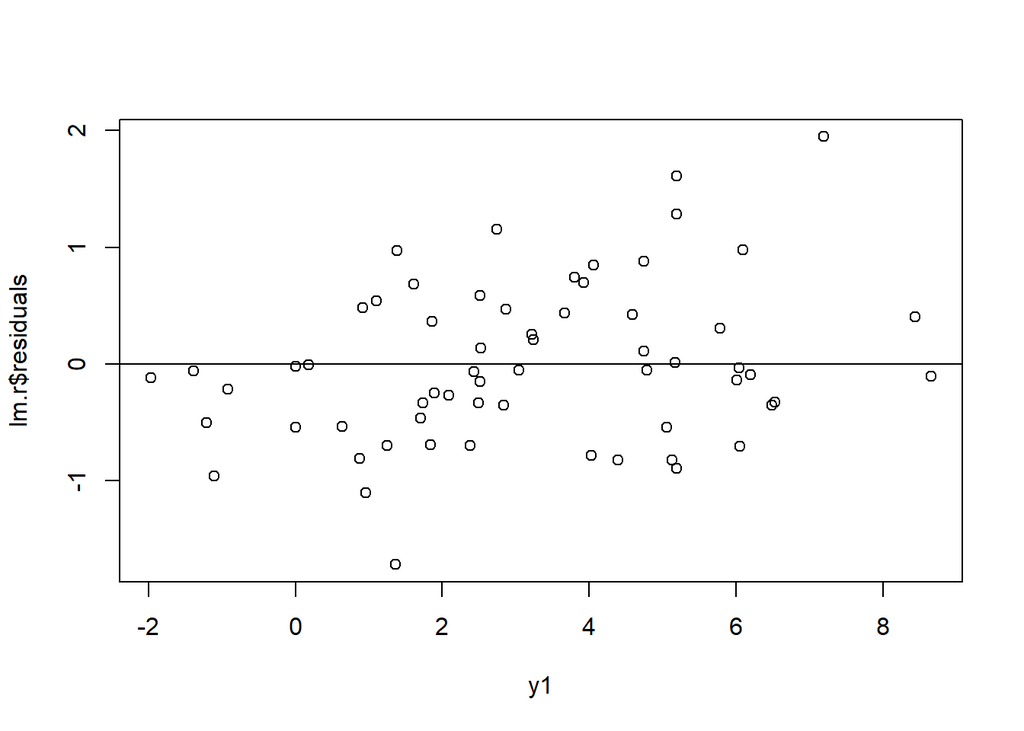

```r
plot(y1, lm.r$residuals)
abline(h = 0) #dodaje y=0; punkty powinny byc rozrzucone symetrycznie wzgledem tej prostej
```

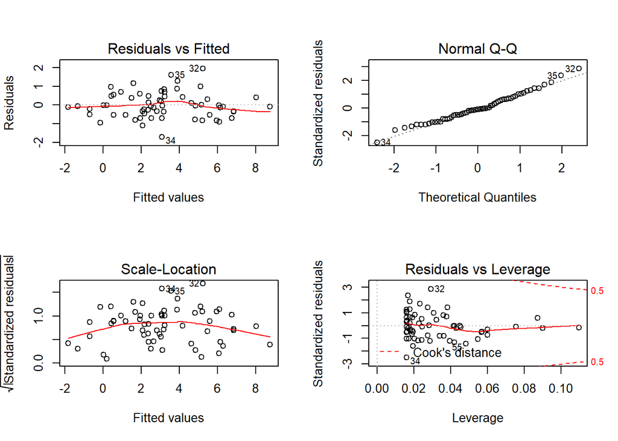

```r
options(repr.plot.width=10, repr.plot.height=5)

par(mfrow = c(2, 2));
plot(lm.r)
```

Po zlogarytmowaniu danych orzymaliśmy lepszy model - dane mają charakter rozkładu normalnego

```r
#przewidywanie nowych wartosci
exp(predict(lm.r, data.frame(x = log(62)), level = 0.95, interval = "confidence"))
```

```
##             fit          lwr          upr
## 1    21.1440779   17.7228408 2.522575e+01
## 2     4.8699047    3.9388808 6.020993e+00
## 3    10.5949034    8.7966247 1.276080e+01
## 4   855.4877845  617.8170109 1.184589e+03
## 5   125.8799317  101.2069146 1.565679e+02
## 6   102.5526637   83.1773354 1.264413e+02
## 7    64.1885071   52.9431443 7.782244e+01
## 8     8.7082455    7.1924304 1.054352e+01
## 9    24.8219829   20.8065777 2.961231e+01
## 10    4.4441850    3.5804570 5.516274e+00
## 11    1.5090003    1.1499680 1.980126e+00
## 12    7.9415772    6.5408408 9.642285e+00
## 13    8.4552595    6.9773787 1.024617e+01
## 14    0.1575706    0.1038466 2.390880e-01
```

[output cut: 48 more lines]

## Zadanie2

Rozważ dane dotyczące wczasowiczów spędzających czas nad morzem w miejscowości $X$. Pierwsza kolumna określa dzienną liczbę incydentów (takie jak wypadki/utonięcia), druga zawiera informacje o liczbie sprzedanych lodów w ciągu kolejnych dni. Zbuduj odpowiedni model liniowy a następnie skomentuj otrzymane wyniki. Czy dostrzegasz pewne niebezpieczeństwo?

```r
x = c(56, 87, 92, 45, 87, 12, 102, 88, 17, 10) #liczba incydentow
y = c(267, 406, 485, 279, 417, 109, 538, 410, 58, 31) #liczba sprzedanych lodow

data.frame(x=x, y=y)
```

```
##      x   y
## 1   56 267
## 2   87 406
## 3   92 485
## 4   45 279
## 5   87 417
## 6   12 109
## 7  102 538
## 8   88 410
## 9   17  58
## 10  10  31
```

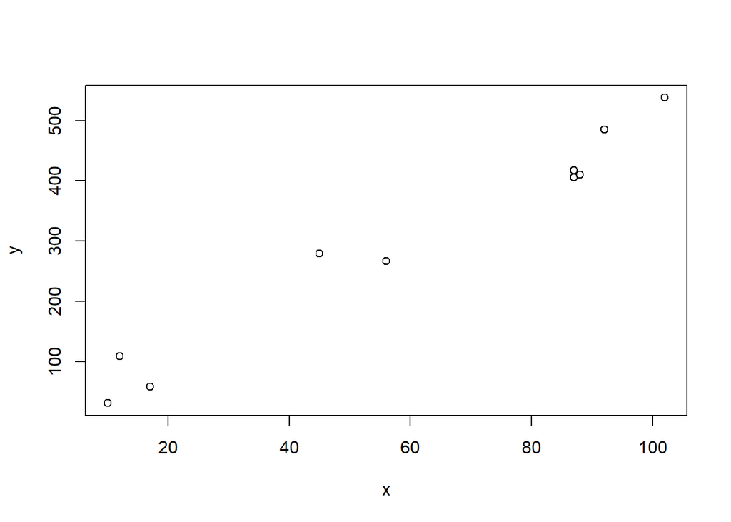

```r
plot(x,y)
```

```r
cor(x,y)
```

```
## [1] 0.9831755
```

```r
lm.r = lm(y ~ x) #budujemy model regresji liniowej y=ax+b
print(summary(lm.r))
```

```
##
## Call:
## lm(formula = y ~ x)
##
## Residuals:
##    Min     1Q Median     3Q    Max
## -33.02 -27.73 -16.38  29.01  50.62
##
## Coefficients:
##             Estimate Std. Error t value Pr(>|t|)
## (Intercept)   7.6189    22.1958   0.343     0.74
## x             4.9057     0.3222  15.224 3.44e-07 ***
## ---
## Signif. codes:  0 '***' 0.001 '**' 0.01 '*' 0.05 '.' 0.1 ' ' 1
##
## Residual standard error: 35.19 on 8 degrees of freedom
## Multiple R-squared:  0.9666, Adjusted R-squared:  0.9625
## F-statistic: 231.8 on 1 and 8 DF,  p-value: 3.435e-07
```

```r
print(coef(lm.r)) #same wspolczynniki
```

```
## (Intercept)           x
##    7.618869    4.905724
```

```r
confint(lm.r, level = 0.95) #przedzial ufnosci dla parametrow modelu
```

```
##                  2.5 %   97.5 %
## (Intercept) -43.564627 58.80236
## x             4.162637  5.64881
```

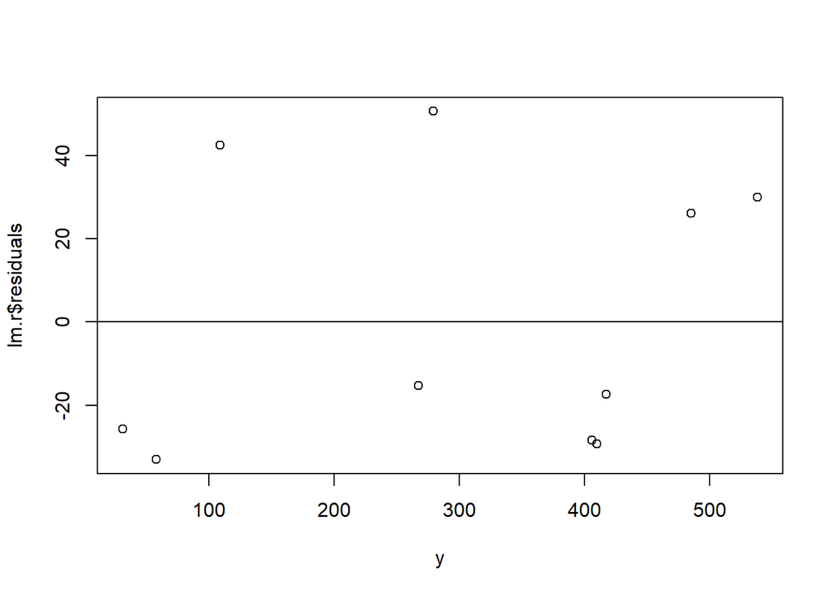

```r
plot(y, lm.r$residuals)
abline(h = 0) #dodaje y=0; punkty powinny byc rozrzucone symetrycznie wzgledem tej prostej
```

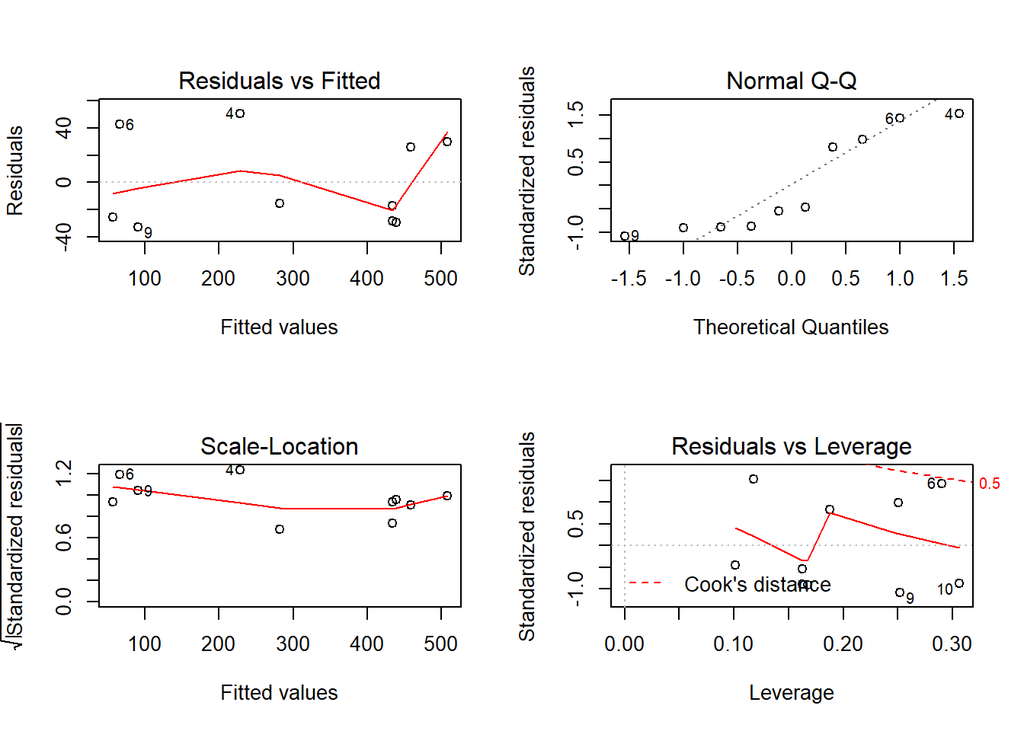

```r
options(repr.plot.width=10, repr.plot.height=5)

par(mfrow = c(2, 2));
plot(lm.r)
```

Występuje zależność, ale nie mamy do czynienia z ciągiem przyczynowo-skutkowym